# Creating beautiful tables in R with {gt} - 5 Case studies

## 5.1 Fitness pricing

In this chapter we’re going to build this Fitness pricing table I found [online](https://codepen.io/supacode/pen/ExjbmgG). It’s not really a data table but it’s a fun exercise to build this.

Fitness Pricing Table

| Standard |  | Popular |  | Golden |  | Ultimate |
| --- | --- | --- | --- | --- | --- | --- |
| $15/month |  | $25/month |  | $35/month |  | $50/month |
| Beginner Classes Training Overview Personal Training Olympic Weightlifting Foundation Training |  | Beginner Classes Training Overview Personal Training Olympic Weightlifting Foundation Training |  | Beginner Classes Training Overview Personal Training Olympic Weightlifting Foundation Training |  | Beginner Classes Training Overview Personal Training Olympic Weightlifting Foundation Training |
| [Book now](https://www.youtube.com/watch?v=dQw4w9WgXcQ) |  | [Book now](https://www.youtube.com/watch?v=dQw4w9WgXcQ) |  | [Book now](https://www.youtube.com/watch?v=dQw4w9WgXcQ) |  | [Book now](https://www.youtube.com/watch?v=dQw4w9WgXcQ) |

Design/Inspiration: @supacode | {gt} Remake: @rappa753

Notice that I’ve even added a little interactive element. You can hover over the booking button. And clicking it redirects you to a certain web page. To get started, let us define the data we need.

```r
library(tidyverse)
library(gt)
levels <- c('Standard', 'Popular', 'Golden', 'Ultimate')
prices <- c(15, 25, 35, 50)
names(prices) <- levels
prices
## Standard  Popular   Golden Ultimate
##       15       25       35       50

features <- c('Beginner Classes', 'Training Overview', 'Personal Training', 'Olympic Weightlifting', 'Foundation Training')

dat <- tibble(
  level = levels,
  monthly_price = prices[levels],
  features = list(features[1], features[1:2], features[1:3], features),
  booking_link = 'https://www.youtube.com/watch?v=dQw4w9WgXcQ'
) |>
  unnest(features) |>
  select(level, features)
dat
## # A tibble: 11 × 2
##    level    features
##    <chr>    <chr>
##  1 Standard Beginner Classes
##  2 Popular  Beginner Classes
##  3 Popular  Training Overview
##  4 Golden   Beginner Classes
##  5 Golden   Training Overview
##  6 Golden   Personal Training
##  7 Ultimate Beginner Classes
##  8 Ultimate Training Overview
##  9 Ultimate Personal Training
## 10 Ultimate Olympic Weightlifting
## 11 Ultimate Foundation Training

level_colors <- c(
  Standard = "#c40d53",
  Popular = "#26559b",
  Golden = "#f90",
  Ultimate =  "#0d833e"
)
level_colors
##  Standard   Popular    Golden  Ultimate
## "#c40d53" "#26559b"    "#f90" "#0d833e"
```

### 5.1.1 Feature tables

From this we can create a table for the features of a single tier, e.g. the “Popular” tier. First, we need to create the data set for this. To do so, we’re going to proceed as follows:

1. Filter `dat` so that we have only the features of our current tier
2. Add a new column `in_level` and set it to true (since all the filtered features are in the tier)
3. Expand the tibble so that the other features are also present in the data set (with `in_level` false)

```r
level <- 'Popular'
dat |>
    ## We use !! here so that this filter actually filters
    filter(level == !!level) |>
    mutate(in_level = TRUE)  |>
    complete(
      expand(dat, features),
      fill = list(in_level = FALSE, level = 'Popular')
    )
## # A tibble: 5 × 3
##   features              level   in_level
##   <chr>                 <chr>   <lgl>
## 1 Beginner Classes      Popular TRUE
## 2 Foundation Training   Popular FALSE
## 3 Olympic Weightlifting Popular FALSE
## 4 Personal Training     Popular FALSE
## 5 Training Overview     Popular TRUE
```

Next, we can throw away the `level` column and sort the rows by the features (which we saved in the vector `features`).

```r
level <- 'Popular'
dat |>
    ## We use !! here so that this filter actually filters
    filter(level == !!level) |>
    mutate(in_level = TRUE)  |>
    complete(
      expand(dat, features),
      fill = list(in_level = FALSE, level = 'Popular')
    ) |>
    select(in_level, features) |>
    arrange(features = fct_relevel(features, !!features))
## # A tibble: 5 × 2
##   in_level features
##   <lgl>    <chr>
## 1 TRUE     Beginner Classes
## 2 TRUE     Training Overview
## 3 FALSE    Personal Training
## 4 FALSE    Olympic Weightlifting
## 5 FALSE    Foundation Training
```

Finally, we turn the column `in_level` into fontawesome icons. The colors of these icons are taken from our vector `level_colors`.

```r
level_data <- dat |>
    ## We use !! here so that this filter actually filters
    filter(level == !!level) |>
    mutate(in_level = TRUE)  |>
    complete(
      expand(dat, features),
      fill = list(in_level = FALSE)
    ) |>
    select(in_level, features) |>
    arrange(features = fct_relevel(features, !!features)) |>
    mutate(
      in_level = ifelse(
        in_level,
        fontawesome::fa('check', fill = level_colors[level]) |> html(),
        fontawesome::fa('xmark', fill = level_colors[level]) |> html()
      )
    )
level_data
## # A tibble: 5 × 2
##   in_level                                                               featu…¹
##   <chr>                                                                  <chr>
## 1 "<svg aria-hidden=\"true\" role=\"img\" viewBox=\"0 0 512 512\" style… Beginn…
## 2 "<svg aria-hidden=\"true\" role=\"img\" viewBox=\"0 0 512 512\" style… Traini…
## 3 "<svg aria-hidden=\"true\" role=\"img\" viewBox=\"0 0 320 512\" style… Person…
## 4 "<svg aria-hidden=\"true\" role=\"img\" viewBox=\"0 0 320 512\" style… Olympi…
## 5 "<svg aria-hidden=\"true\" role=\"img\" viewBox=\"0 0 320 512\" style… Founda…
## # … with abbreviated variable name ¹features
```

Sweet. Now we can turn this into a `{gt}` table. We have to use `fmt_markdown()` on our `in_leel` column so that the icons are actually displayed as icons. While we’re at it, we can style the table a tiny bit. This includes getting rid of the column labels.

```r
level_data |>
    gt() |>
    fmt_markdown(columns = 'in_level') |>
    cols_width(in_level ~ px(25), everything() ~ px(175)) |>
    tab_options(
      column_labels.hidden = TRUE,
      table.font.names = 'Source Sans Pro',
      table_body.border.top.style = 'none',
      table.border.top.style = 'none',
      table_body.border.bottom.style = 'none',
      table.border.bottom.style = 'none',
      table_body.hlines.style = 'none',
    )
```

|  | Beginner Classes |
| --- | --- |
|  | Training Overview |
|  | Personal Training |
|  | Olympic Weightlifting |
|  | Foundation Training |

Alright, this looks already pretty good. We’ll get rid of the grid lines once we have assembled the full table. Of course, we have to create this table for all tiers. So let’s wrap this into a function.

```r
tier_feature_table <- function(level) {
  level_data <- dat |>
    ## We use !! here so that this filter actually filters
    filter(level == !!level) |>
    mutate(in_level = TRUE)  |>
    complete(
      expand(dat, features),
      fill = list(in_level = FALSE)
    ) |>
    select(in_level, features) |>
    arrange(features = fct_relevel(features, !!features)) |>
    mutate(
      in_level = ifelse(
        in_level,
        fontawesome::fa('check', fill = level_colors[level]) |> html(),
        fontawesome::fa('xmark', fill = level_colors[level]) |> html()
      )
    )

  level_data |>
    gt() |>
    fmt_markdown(columns = 'in_level') |>
    cols_width(in_level ~ px(25), everything() ~ px(175)) |>
    tab_options(
      column_labels.hidden = TRUE,
      table.font.names = 'Source Sans Pro',
      table_body.border.top.style = 'none',
      table.border.top.style = 'none',
      table_body.border.bottom.style = 'none',
      table.border.bottom.style = 'none',
      table_body.hlines.style = 'none',
    )
}
```

**Standard**

```r
tier_feature_table('Standard')
```

|  | Beginner Classes |
| --- | --- |
|  | Training Overview |
|  | Personal Training |
|  | Olympic Weightlifting |
|  | Foundation Training |

**Popular**

```r
tier_feature_table('Popular')
```

|  | Beginner Classes |
| --- | --- |
|  | Training Overview |
|  | Personal Training |
|  | Olympic Weightlifting |
|  | Foundation Training |

**Golden**

```r
tier_feature_table('Golden')
```

|  | Beginner Classes |
| --- | --- |
|  | Training Overview |
|  | Personal Training |
|  | Olympic Weightlifting |
|  | Foundation Training |

**Ultimate**

```r
tier_feature_table('Ultimate')
```

|  | Beginner Classes |
| --- | --- |
|  | Training Overview |
|  | Personal Training |
|  | Olympic Weightlifting |
|  | Foundation Training |

And we can save all tables as HTML in a tibble. For such occasions, `{gt}` has the function `as_raw_html()`.

```r
tables_tib <- tibble(
  level = levels,
  table = map_chr(levels, ~as_raw_html(tier_feature_table(.)))
) |>
  pivot_wider(names_from = level, values_from = table)
tables_tib
## # A tibble: 1 × 4
##   Standard                                                Popular Golden Ultim…¹
##   <chr>                                                   <chr>   <chr>  <chr>
## 1 "<div id=\"ntkmgsxdof\" style=\"padding-left:0px;paddi… "<div … "<div… "<div …
## # … with abbreviated variable name ¹Ultimate
```

### 5.1.2 Prices and links

We can create similar tibbles for our prices. Really, this table contains only the HTML-text for the monthly price tag where the price is larger than the rest.

```r
price_tib <- tibble(
  level = levels,
  price = paste0('$<span style="font-size:40px;">', prices, '</span>/month')
) |>
  pivot_wider(names_from = level, values_from = price)
price_tib
## # A tibble: 1 × 4
##   Standard                                           Popular      Golden Ultim…¹
##   <chr>                                              <chr>        <chr>  <chr>
## 1 "$<span style=\"font-size:40px;\">15</span>/month" "$<span sty… "$<sp… "$<spa…
## # … with abbreviated variable name ¹Ultimate
```

Next, we can create yet another similar tibble for our URLs. For this, I use the `a()` function from `{htmltools}` here. More precisely, I have wrapped `a()` into a function `style_url()` that turns a URL into a colored box.

```r
style_url <- function(link, color) {
  htmltools::a(
      href = link,
      "Book now",
      style = glue::glue("border-radius: 5px;color: white;background-color: {color};border-radius: 5px;padding: 8px 20px;display: inline-block;text-decoration:none")
  )
}

url_tib <- tibble(
  level = levels,
  level_colors = level_colors[level],
  booking_link = 'https://www.youtube.com/watch?v=dQw4w9WgXcQ'
) |>
  mutate(
    booking_link = map2(booking_link, level_colors, style_url),
    booking_link = map_chr(booking_link, ~as.character(.x))
  ) |>
  select(-level_colors) |>
  pivot_wider(names_from = level, values_from = booking_link)
url_tib
## # A tibble: 1 × 4
##   Standard                                                Popular Golden Ultim…¹
##   <chr>                                                   <chr>   <chr>  <chr>
## 1 "<a href=\"https://www.youtube.com/watch?v=dQw4w9WgXcQ… "<a hr… "<a h… "<a hr…
## # … with abbreviated variable name ¹Ultimate
```

### 5.1.3 Assembling the tables

Now we can put everything together. And in order to get white space between the tiers, we insert a few empty dummy columns.

```r
levels_text_size <- px(30)

unstyled_fitness_table <- bind_rows(price_tib, tables_tib, url_tib) |>
  mutate(dummy1 = '', .after = 1) |>
  mutate(dummy2 = '', .after = 3) |>
  mutate(dummy3 = '', .after = 5) |>
  gt(id = 'fitness_table') |>
  fmt_markdown(columns = everything()) |>
  cols_align(align = 'center') |>
  cols_label(
    dummy1 = '',
    dummy2 = '',
    dummy3 = ''
  ) |>
  cols_width(
    dummy1 ~ px(15),
    dummy2 ~ px(15),
    dummy3 ~ px(15)
  )  |>
  tab_header(
    title = 'Fitness Pricing Table'
  ) |>
  tab_footnote(
    footnote = 'Design/Inspiration: @supacode | {gt} Remake: @rappa753',
    placement = 'right'
  )
unstyled_fitness_table
```

Fitness Pricing Table

| Standard |  | Popular |  | Golden |  | Ultimate |
| --- | --- | --- | --- | --- | --- | --- |
| $15/month |  | $25/month |  | $35/month |  | $50/month |
| Beginner Classes Training Overview Personal Training Olympic Weightlifting Foundation Training |  | Beginner Classes Training Overview Personal Training Olympic Weightlifting Foundation Training |  | Beginner Classes Training Overview Personal Training Olympic Weightlifting Foundation Training |  | Beginner Classes Training Overview Personal Training Olympic Weightlifting Foundation Training |
| [Book now](https://www.youtube.com/watch?v=dQw4w9WgXcQ) |  | [Book now](https://www.youtube.com/watch?v=dQw4w9WgXcQ) |  | [Book now](https://www.youtube.com/watch?v=dQw4w9WgXcQ) |  | [Book now](https://www.youtube.com/watch?v=dQw4w9WgXcQ) |

Design/Inspiration: @supacode | {gt} Remake: @rappa753

And the rest is “just” a series of `tab_style()` calls plus `tab_options()` and a bit of custom CSS.

```r
unstyled_fitness_table |>
  tab_style(
    style = list(
      cell_fill(color = level_colors['Standard']),
      cell_text(color = 'white', weight = 'bold')
    ),
    locations = list(
      cells_body(columns = 'Standard', rows = 1),
      cells_column_labels(column = 'Standard')
    )
  ) |>
  tab_style(
    style = list(
      cell_fill(color = level_colors['Popular']),
      cell_text(color = 'white', weight = 'bold')
    ),
    locations = list(
      cells_body(columns = 'Popular', rows = 1),
      cells_column_labels(column = 'Popular')
    )
  ) |>
  tab_style(
    style = list(
      cell_fill(color = level_colors['Golden']),
      cell_text(color = 'white', weight = 'bold')
    ),
    locations = list(
      cells_body(columns = 'Golden', rows = 1),
      cells_column_labels(column = 'Golden')
    )
  ) |>
  tab_style(
    style = list(
      cell_fill(color = level_colors['Ultimate']),
      cell_text(color = 'white', weight = 'bold')
    ),
    locations = list(
      cells_body(columns = 'Ultimate', rows = 1),
      cells_column_labels(column = 'Ultimate')
    )
  ) |>
  tab_style(
    style = cell_text(size = levels_text_size),
    locations = cells_column_labels()
  ) |>
  tab_style(
    style = list(cell_fill(color = 'white')),
    locations = list(
      cells_body(columns = contains('dummy')),
      cells_column_labels(columns = contains('dummy'))
    )
  ) |>
  tab_style(
    style = cell_borders(sides = 'bottom', color = '#D3D3D3'),
    locations = cells_body(rows = 3, columns = c(1, 3, 5, 7))
  ) |>
  tab_options(
    table_body.border.top.style = 'none',
    table.border.top.style = 'none',
    table_body.border.bottom.style = 'none',
    table.border.bottom.style = 'none',
    table_body.hlines.style = 'none',
    table_body.vlines.style = 'solid',
    column_labels.border.top.style = 'none',
    column_labels.border.bottom.style = 'none',
    column_labels.border.lr.style = 'solid', # not working, set in css
    column_labels.border.lr.width = px(1),
    column_labels.padding = px(1),
    data_row.padding = px(2),
    table.font.names = 'Source Sans Pro',
    heading.title.font.size = px(45),
    heading.padding = px(10),
    heading.border.bottom.style = 'none'
  ) |>
  opt_css(
    '#fitness_table .gt_footnote {
      text-align: right; padding-top: 5px;
    }

    #fitness_table .gt_title {
      font-family:"Oleo Script";
    }

    #fitness_table .gt_col_heading {
      border-left-style:solid;
      border-right-style:solid;
    }

    #fitness_table thead, tbody, tfoot, tr, td, th {
      border-color: inherit;
      border-style: solid;
      border-width: 0;
    }

    #fitness_table a {
    &:hover {
        transform: translateY(-3px);
        box-shadow: 0 5px 5px rgba(0, 0, 0, 0.4);
      }
      &:active {
        box-shadow: inset 0 -3px 5px rgba(0, 0, 0, 0.4);
      }
    }

    '
  )
```

Fitness Pricing Table

| Standard |  | Popular |  | Golden |  | Ultimate |
| --- | --- | --- | --- | --- | --- | --- |
| $15/month |  | $25/month |  | $35/month |  | $50/month |
| Beginner Classes Training Overview Personal Training Olympic Weightlifting Foundation Training |  | Beginner Classes Training Overview Personal Training Olympic Weightlifting Foundation Training |  | Beginner Classes Training Overview Personal Training Olympic Weightlifting Foundation Training |  | Beginner Classes Training Overview Personal Training Olympic Weightlifting Foundation Training |
| [Book now](https://www.youtube.com/watch?v=dQw4w9WgXcQ) |  | [Book now](https://www.youtube.com/watch?v=dQw4w9WgXcQ) |  | [Book now](https://www.youtube.com/watch?v=dQw4w9WgXcQ) |  | [Book now](https://www.youtube.com/watch?v=dQw4w9WgXcQ) |

Design/Inspiration: @supacode | {gt} Remake: @rappa753

## 5.2 NYT bestseller

The New York Times **Best Selling Authors**  
Top authors by decade. Ranking based on number of weeks author appeared on list. Sparkline depicts total weeks  
by year (counts multiple books). Top performing book included beneath each author's name. Data from Post45 Data Collective.

1960s

1

176 WEEKS ON THE LIST  
Allen Drury  
Advise And Consent

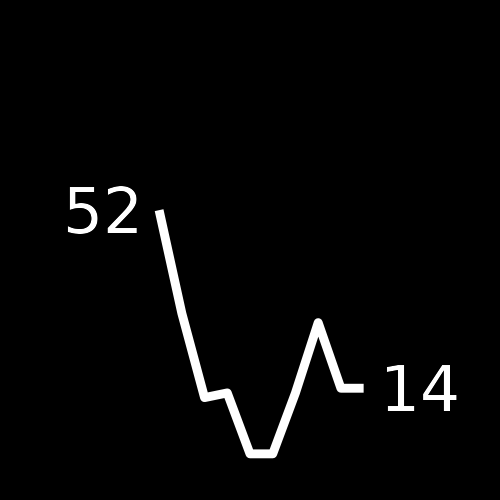

2

158 WEEKS ON THE LIST  
John O'Hara  
Elizabeth Appleton

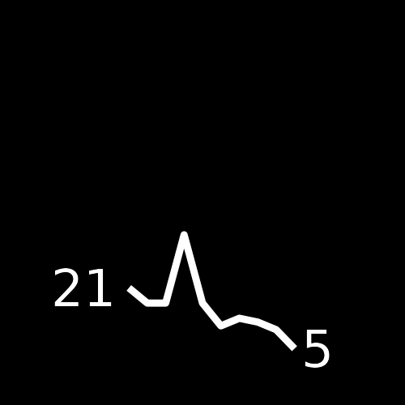

3

157 WEEKS ON THE LIST  
Taylor Caldwell  
Testimony Of Two Men

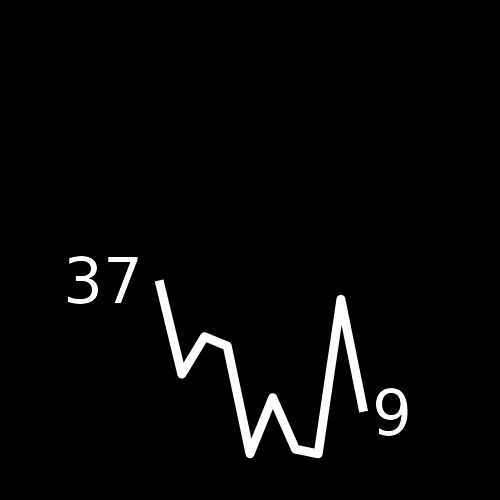

4

136 WEEKS ON THE LIST  
Irving Wallace  
The Man

[figure not shown]

5

135 WEEKS ON THE LIST  
Leon Uris  
Topaz

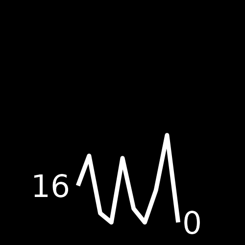

1970s

1

172 WEEKS ON THE LIST  
Richard Bach  
Illusions

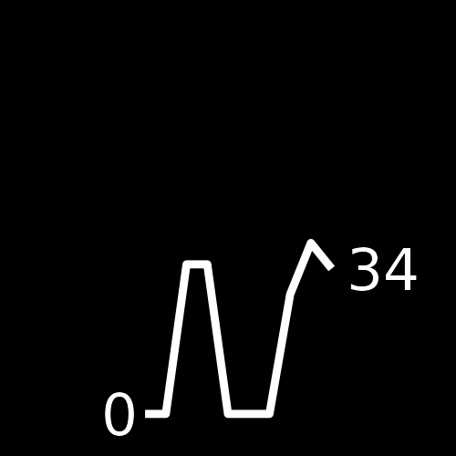

2

125 WEEKS ON THE LIST  
Robert Ludlum  
The Matarese Circle

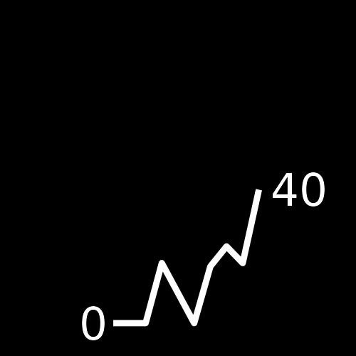

3

123 WEEKS ON THE LIST  
Herman Wouk  
The Winds Of War

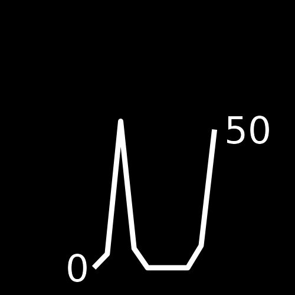

4

119 WEEKS ON THE LIST  
Agatha Christie  
Curtain

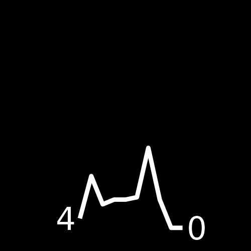

5

119 WEEKS ON THE LIST  
Frederick Forsyth  
The Odessa File

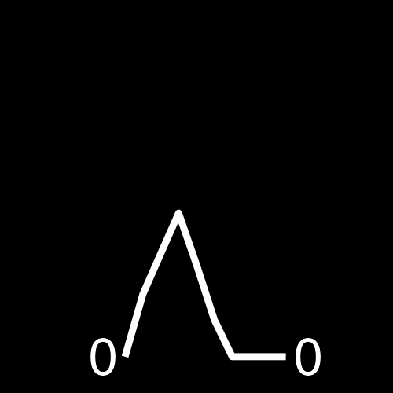

1980s

1

336 WEEKS ON THE LIST  
Stephen King  
Firestarter

[figure not shown]

2

271 WEEKS ON THE LIST  
Danielle Steel  
Changes

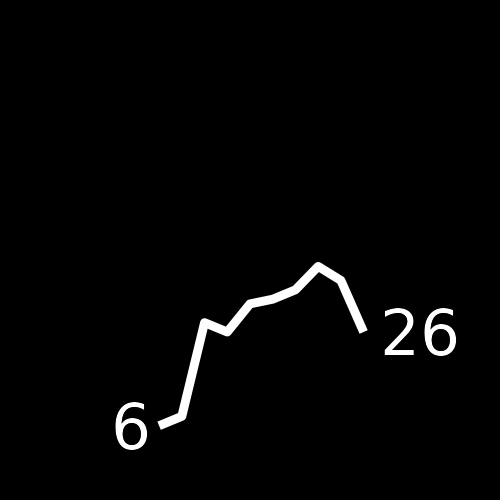

3

205 WEEKS ON THE LIST  
James A. Michener  
The Covenant

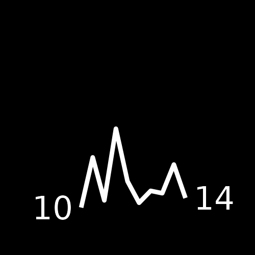

4

176 WEEKS ON THE LIST  
Tom Clancy  
Red Storm Rising

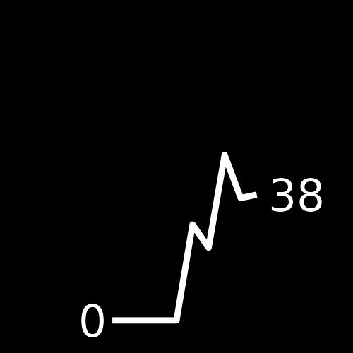

5

170 WEEKS ON THE LIST  
Robert Ludlum  
The Parsifal Mosaic

[figure not shown]

1990s

1

311 WEEKS ON THE LIST  
Danielle Steel  
The Gift

[figure not shown]

2

307 WEEKS ON THE LIST  
John Grisham  
The Pelican Brief

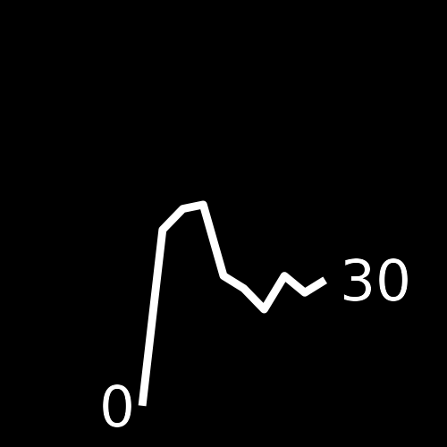

3

244 WEEKS ON THE LIST  
Stephen King  
The Stand

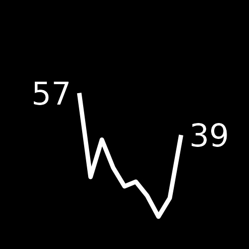

4

212 WEEKS ON THE LIST  
Robert Waller  
The Bridges Of Madison County

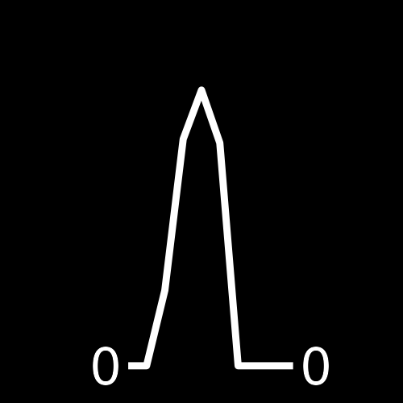

5

192 WEEKS ON THE LIST  
Mary Higgins Clark  
Loves Music, Loves To Dance

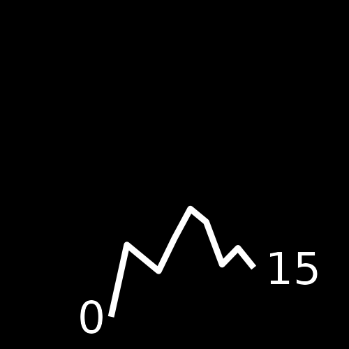

2000s

1

232 WEEKS ON THE LIST  
John Grisham  
Skipping Christmas

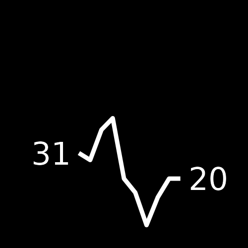

2

218 WEEKS ON THE LIST  
Dan Brown  
The Da Vinci Code

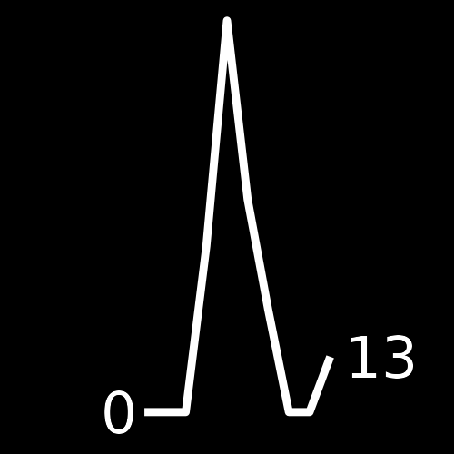

3

200 WEEKS ON THE LIST  
Danielle Steel  
The House On Hope Street

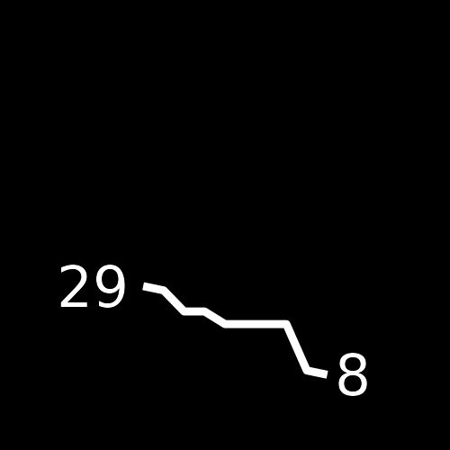

4

178 WEEKS ON THE LIST  
James Patterson  
Cross

[figure not shown]

5

176 WEEKS ON THE LIST  
Nicholas Sparks  
A Bend In The Road

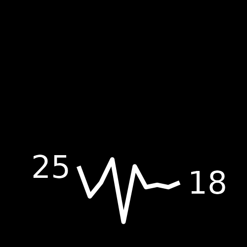

2010s

1

216 WEEKS ON THE LIST  
John Grisham  
Sycamore Row

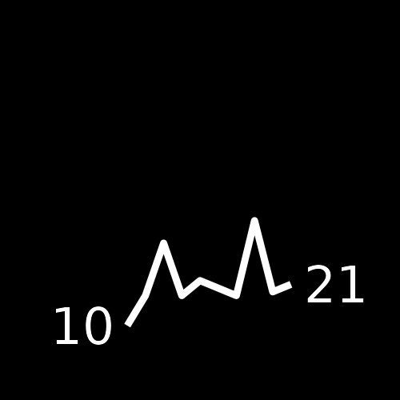

2

207 WEEKS ON THE LIST  
David Baldacci  
The Escape

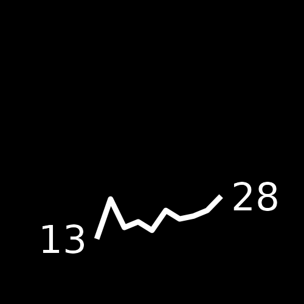

3

157 WEEKS ON THE LIST  
Danielle Steel  
The Mistress

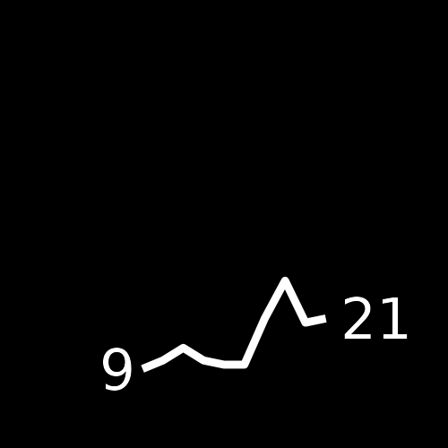

4

157 WEEKS ON THE LIST  
Stephen King  
11/22/63

[figure not shown]

5

132 WEEKS ON THE LIST  
Anthony Doerr  
All The Light We Cannot See

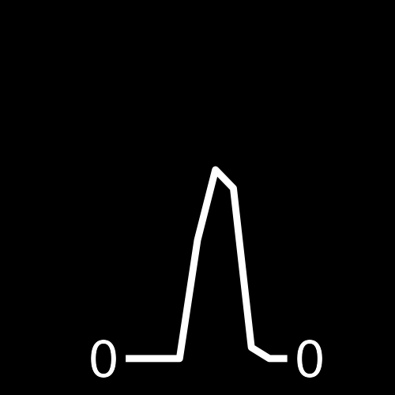

{ggplot2} Original: @tanya_shapiro | {gt} recreation: @rappa753

### 5.2.1 Data Preparation

The first thing we need to do is get the data. This requires a bit of data wrangling on the underlying [TidyTuesdaty data set](https://github.com/rfordatascience/tidytuesday/blob/master/data/2022/2022-05-10/readme.md). The following code finds the top 5 authors by decade, their best book and the data for the sparkline plot.

```r
# Book finder helper function
find_best_book <- function(decade, author) {
  best_books <- nyt_dat |>
    filter(decade == !!decade, author == !!author) |>
    count(title, sort = TRUE)

  best_books[[1, 'title']] |> str_to_title()
}

# Sparkline helper function
find_number_of_weeks_per_year <- function(decade, author){
  nyt_dat |>
    filter(decade == !!decade, author == !!author) |>
    count(year, name = 'weeks') |>
    complete(tibble(year = decade:(decade + 9)), fill = list(weeks = 0)) |>
    arrange(year)  |>
    pull(weeks)
}

# Data from the TidyTuesday repo
nyt_dat <- readr::read_tsv('https://raw.githubusercontent.com/rfordatascience/tidytuesday/master/data/2022/2022-05-10/nyt_full.tsv') |>
  mutate(decade = (year %/% 10) * 10)

# Find top 5 authors
top5_authors_by_decade <- nyt_dat |>
  filter(between(year, 1960, 2019)) |>
  count(author, decade, sort = T, name = 'weeks') |>
  group_by(decade) |>
  slice_max(weeks, n = 5) |>
  ungroup()


# Find their best book and the info for the sparlines
top5_authors_and_book_by_decade <- top5_authors_by_decade |>
  mutate(
    best_book = map2_chr(decade, author, find_best_book),
    sparkline_weeks = map2(decade, author, find_number_of_weeks_per_year)
  )
top5_authors_and_book_by_decade
## # A tibble: 30 × 5
##    author            decade weeks best_book            sparkline_weeks
##    <chr>              <dbl> <int> <chr>                <list>
##  1 Allen Drury         1960   176 Advise And Consent   <int [10]>
##  2 John O'Hara         1960   158 Elizabeth Appleton   <int [10]>
##  3 Taylor Caldwell     1960   157 Testimony Of Two Men <int [10]>
##  4 Irving Wallace      1960   136 The Man              <int [10]>
##  5 Leon Uris           1960   135 Topaz                <int [10]>
##  6 Richard Bach        1970   172 Illusions            <int [10]>
##  7 Robert Ludlum       1970   125 The Matarese Circle  <int [10]>
##  8 Herman Wouk         1970   123 The Winds Of War     <int [10]>
##  9 Agatha Christie     1970   119 Curtain              <int [10]>
## 10 Frederick Forsyth   1970   119 The Odessa File      <int [10]>
## # … with 20 more rows
```

Next, we find images of the authors online and save them in a tibble `image_links`. This tibble can then be joined with `top5_authors_and_book_by_decade`.

```r
image_links <- tibble(
  author = top5_authors_and_book_by_decade |> pull(author) |> unique(),
  img = c(
    'https://images.gr-assets.com/authors/1327446818p8/77616.jpg',
    'https://upload.wikimedia.org/wikipedia/commons/thumb/c/c5/John_O%27Hara_cph.3b08576.jpg/1024px-John_O%27Hara_cph.3b08576.jpg',
    'https://upload.wikimedia.org/wikipedia/commons/8/88/Taylor_caldwell_a.jpg',
    'https://upload.wikimedia.org/wikipedia/commons/thumb/0/0c/Irving_Wallace%2C_1972.jpg/330px-Irving_Wallace%2C_1972.jpg',
    'https://upload.wikimedia.org/wikipedia/commons/d/d6/Leon_Uris_%28cropped%29.jpg',
    'https://images-na.ssl-images-amazon.com/images/I/41RMdx8BJHL.__01_SX120_CR0,0,120,120__.jpg',
    'https://upload.wikimedia.org/wikipedia/en/a/a2/Robert_Ludlum_%281927-2001%29.jpg',
    'https://upload.wikimedia.org/wikipedia/commons/thumb/4/49/Herman_Wouk_%28cropped%29.jpg/330px-Herman_Wouk_%28cropped%29.jpg',
    'https://upload.wikimedia.org/wikipedia/commons/thumb/c/cf/Agatha_Christie.png/330px-Agatha_Christie.png',
    'https://upload.wikimedia.org/wikipedia/commons/thumb/9/9d/Frederick_Forsyth_-_01.jpg/375px-Frederick_Forsyth_-_01.jpg',
    'https://upload.wikimedia.org/wikipedia/commons/thumb/e/e3/Stephen_King%2C_Comicon.jpg/330px-Stephen_King%2C_Comicon.jpg',
    'https://images1.penguinrandomhouse.com/author/29599',
    'https://upload.wikimedia.org/wikipedia/commons/thumb/d/dc/James_Albert_Michener_%C2%B7_DN-SC-92-05368.JPEG/330px-James_Albert_Michener_%C2%B7_DN-SC-92-05368.JPEG',
    'https://upload.wikimedia.org/wikipedia/commons/thumb/9/98/Tom_Clancy_at_Burns_Library_cropped.jpg/330px-Tom_Clancy_at_Burns_Library_cropped.jpg',
    'https://upload.wikimedia.org/wikipedia/commons/thumb/5/5f/Grisham_John_by_C_Harrison_.jpg/300px-Grisham_John_by_C_Harrison_.jpg',
    'https://upload.wikimedia.org/wikipedia/en/7/70/Robert_James_Waller.jpg',
    'https://upload.wikimedia.org/wikipedia/commons/thumb/b/bf/Mary_Higgins_Clark_at_the_Mazza_Museum.jpg/330px-Mary_Higgins_Clark_at_the_Mazza_Museum.jpg',
    'https://upload.wikimedia.org/wikipedia/commons/thumb/8/8b/Dan_Brown_bookjacket_cropped.jpg/330px-Dan_Brown_bookjacket_cropped.jpg',
    'https://upload.wikimedia.org/wikipedia/commons/1/1d/James_Patterson.jpg',
    'https://upload.wikimedia.org/wikipedia/commons/a/af/Nicholas-Sparks-Autograph-1-4-06.jpg',
    'https://upload.wikimedia.org/wikipedia/commons/thumb/3/3d/David_Baldacci_-_2015_National_Book_Festival_%286%29.jpg/330px-David_Baldacci_-_2015_National_Book_Festival_%286%29.jpg',
    'https://upload.wikimedia.org/wikipedia/commons/thumb/6/61/Anthony_Doerr_%282015%29.jpg/330px-Anthony_Doerr_%282015%29.jpg'
  )
)

full_dat <- top5_authors_and_book_by_decade |>
  left_join(image_links)
```

### 5.2.2 Sparklines

Next, we can create the sparklines for each table entry. This requires two steps.

1. Find the highest number per year of how many times an author appeared in the bestseller list. This number can be higher than 52 due to multiple books. Knowing this number ensures that all of our sparklines are using the same y-axis.
2. Build a function that transforms the vector of weeks per year into a ggplot. Keep in mind that the sizes need to be large in the ggplot so that they are legible in the small table image later on.

```r
# can be higher than 52 bc of multiple books
highest_week_count_per_year <- full_dat |>
  pull(sparkline_weeks) |>
  map_dbl(max) |>
  max()

create_sparkline <- function(sparkline) {
  ggplot() +
    geom_line(
      mapping = aes(x = seq_along(sparkline), y = sparkline),
      color = 'white',
      linewidth = 3
    ) +
    annotate(
      'text',
      x = c(1, 10),
      y = sparkline[c(1, 10)],
      label = sparkline[c(1, 10)],
      color = 'white',
      hjust = c(1.2, -0.2),
      size = 16
    ) +
    coord_cartesian(xlim = c(-5, 15), ylim = c(0, highest_week_count_per_year)) +
    theme_void() +
    theme(plot.background = element_rect(fill = 'black'))
}
create_sparkline(25 * runif(10))
```

[figure not shown]

### 5.2.3 Decade table

Ok great, we have a function for sparklines now. Now, let us create the table for a singledecade. For that we will need three things.

1. A function that maps the number of weeks to a color (for the little colored circles)
2. A function that creates the HTML code for the small colored circles
3. A function that stacks the following information as we’ve seen in the intial table using HTML:
   - number of weeks
   - author name
   - author’s best book
   - HTML code of circle

These three functions look like this.

```r
# Maps number of weeks to colors
map2color <- function(x, pal = rev(RColorBrewer::brewer.pal(11, 'Spectral')), limits=NULL){
    if(is.null(limits)) limits <- range(x)
    pal[findInterval(x,seq(limits[1],limits[2],length.out=length(pal)+1), all.inside=TRUE)]
}

# Creates colored circle which is really just a styled <span> tag
create_point_span <- function(color, size) {
  glue::glue(
    '<span style="height: {size}em;width: {size}em;background-color: {color};border-radius: 50%;margin-top:4px;display:inline-block;margin-left:2px;"></span>'
  )
}

# Formats the author infos via styled <span> tags and line breaks <br>
format_text <- function(weeks, author, best_book, colors) {
  glue::glue(
    '<span style = "color:white;font-weight:lighter;font-size:12pt;">{str_to_upper(weeks)} WEEKS ON THE LIST</span> {create_point_span(colors, 0.75)}',
    '<br>',
    '<span style = "color:white;font-weight:bold;font-size:22pt;">{author}</span>',
    '<br>',
    '<span style = "color:white;font-size:12pt;">{best_book}</span>'
  )
}
```

Now we can apply these functions to get our data set ready for `gt()`. Here, we will use the data of the 1960s.

```r
decade <- 1960
decade_data <- full_dat |>
  # Create colors before filtering (for consistent colors across decades)
  mutate(color = map2color(weeks)) |>
  filter(decade == !!decade) |>
  mutate(
    # Shorten long names
    author = if_else(
      author == 'Robert James Waller',
      'Robert Waller',
      author
    ),
    # Add ranking (authors are already sorted)
    rank = 1:5,
    # Format decade label
    decade = paste0(decade, 's'),
    # create stacked author info
    joined_text = pmap_chr(
      .l = list(weeks, author, best_book, color),
      format_text
    )
  ) |>
  select(rank, decade, joined_text, sparkline_weeks, img)

decade_data
## # A tibble: 5 × 5
##    rank decade joined_text                                         spark…¹ img
##   <int> <chr>  <chr>                                               <list>  <chr>
## 1     1 1960s  "<span style = \"color:white;font-weight:lighter;f… <int>   http…
## 2     2 1960s  "<span style = \"color:white;font-weight:lighter;f… <int>   http…
## 3     3 1960s  "<span style = \"color:white;font-weight:lighter;f… <int>   http…
## 4     4 1960s  "<span style = \"color:white;font-weight:lighter;f… <int>   http…
## 5     5 1960s  "<span style = \"color:white;font-weight:lighter;f… <int>   http…
## # … with abbreviated variable name ¹sparkline_weeks
```

Perfect. We’re ready to pass this to `gt()`. Once we do that we will

- Use `decade` as `groupname_col` so that the label appears on top
- Turn image URLs into images
- Transform the sparkline data into plots
- Adjust widths so that the texts fit into their column and image are round
- Format the `joined_text` column as Markdown (so that the HTML code is rendered)
- Turn background black so text is legible

```r
img_size <- 75
barely_styled_decade_table <- decade_data |>
  gt(groupname_col = 'decade') |>
  gt_img_circle(column = 'img', height = img_size) |>
  text_transform(
    locations = cells_body(columns = sparkline_weeks),
    fn = function(column) {
      map(column, ~c(str_split_1(., pattern = ', '))) |>
        map(parse_number) |>
        map(create_sparkline) |>
        ggplot_image(height = 75)
    }
  ) |>
  cols_width(
    img ~ px(82), # needs to be a little more than 75px
    joined_text ~ px(300),
    sparkline_weeks ~ px(100)
  ) |>
  fmt_markdown(columns = c('joined_text')) |>
  tab_options(table.background.color = 'black')
barely_styled_decade_table
```

rank

joined_text

sparkline_weeks

img

1960s

1

176 WEEKS ON THE LIST  
Allen Drury  
Advise And Consent

2

158 WEEKS ON THE LIST  
John O'Hara  
Elizabeth Appleton

3

157 WEEKS ON THE LIST  
Taylor Caldwell  
Testimony Of Two Men

4

136 WEEKS ON THE LIST  
Irving Wallace  
The Man

5

135 WEEKS ON THE LIST  
Leon Uris  
Topaz

Finally, we apply some more styling and then our decade table is good to go.

```r
barely_styled_decade_table |>
  tab_style(
    style = cell_text(size = '15pt', weight = 'bold', v_align = 'top'),
    locations = cells_body('rank')
  )  |>
  tab_style(
    locations = cells_row_groups(),
    style = cell_text(align = 'center')
  ) |>
  tab_options(
    table.background.color = 'black',
    table.font.color = 'white',
    table.font.names = 'Open Sans',
    column_labels.hidden = TRUE,
    row_group.border.top.style = 'none',
    row_group.border.bottom.style = 'none',
    table.border.bottom.style = 'solid',
    table.border.bottom.width = px(1),
    table.border.top.style = 'none',
    table_body.border.bottom.style = 'none',
    table_body.border.top.style = 'none',
    heading.border.bottom.style = 'none',
    column_labels.border.top.style = 'none',
  )
```

1960s

1

176 WEEKS ON THE LIST  
Allen Drury  
Advise And Consent

2

158 WEEKS ON THE LIST  
John O'Hara  
Elizabeth Appleton

3

157 WEEKS ON THE LIST  
Taylor Caldwell  
Testimony Of Two Men

4

136 WEEKS ON THE LIST  
Irving Wallace  
The Man

5

135 WEEKS ON THE LIST  
Leon Uris  
Topaz

Now we know how to create one decade table. Time to wrap the logic into a function. We’ll call it `create_decade_table()`. Very original, I know.

```r
create_decade_table <- function(decade, img_size = 75) {
  decade_data <- full_dat |>
    # Create colors before filtering (for consistent colors across decades)
    mutate(color = map2color(weeks)) |>
    filter(decade == !!decade) |>
    mutate(
      # Shorten long names
      author = if_else(
        author == 'Robert James Waller',
        'Robert Waller',
        author
      ),
      # Add ranking (authors are already sorted)
      rank = 1:5,
      # Format decade label
      decade = paste0(decade, 's'),
      # create stacked author info
      joined_text = pmap_chr(
        .l = list(weeks, author, best_book, color),
        format_text
      )
    ) |>
    select(rank, decade, joined_text, sparkline_weeks, img)

  barely_styled_decade_table <- decade_data |>
    gt(groupname_col = 'decade') |>
    gt_img_circle(column = 'img', height = img_size) |>
    text_transform(
      locations = cells_body(columns = sparkline_weeks),
      fn = function(column) {
        map(column, ~c(str_split_1(., pattern = ', '))) |>
          map(parse_number) |>
          map(create_sparkline) |>
          ggplot_image(height = 75)
      }
    ) |>
    cols_width(
      img ~ px(82), # needs to be a little more than 75px
      joined_text ~ px(300),
      sparkline_weeks ~ px(100)
    ) |>
    fmt_markdown(columns = c('joined_text')) |>
    tab_options(table.background.color = 'black')

  barely_styled_decade_table |>
    tab_style(
      style = cell_text(size = '15pt', weight = 'bold', v_align = 'top'),
      locations = cells_body('rank')
    )  |>
    tab_style(
      locations = cells_row_groups(),
      style = cell_text(align = 'center')
    ) |>
    tab_options(
      table.background.color = 'black',
      table.font.color = 'white',
      table.font.names = 'Open Sans',
      column_labels.hidden = TRUE,
      row_group.border.top.style = 'none',
      row_group.border.bottom.style = 'none',
      table.border.bottom.style = 'solid',
      table.border.bottom.width = px(1),
      table.border.top.style = 'none',
      table_body.border.bottom.style = 'none',
      table_body.border.top.style = 'none',
      heading.border.bottom.style = 'none',
      column_labels.border.top.style = 'none',
    )
}
```

**1960s**

```r
create_decade_table(1960)
```

1960s

1

176 WEEKS ON THE LIST  
Allen Drury  
Advise And Consent

2

158 WEEKS ON THE LIST  
John O'Hara  
Elizabeth Appleton

3

157 WEEKS ON THE LIST  
Taylor Caldwell  
Testimony Of Two Men

4

136 WEEKS ON THE LIST  
Irving Wallace  
The Man

5

135 WEEKS ON THE LIST  
Leon Uris  
Topaz

**1970s**

```r
create_decade_table(1970)
```

1970s

1

172 WEEKS ON THE LIST  
Richard Bach  
Illusions

2

125 WEEKS ON THE LIST  
Robert Ludlum  
The Matarese Circle

3

123 WEEKS ON THE LIST  
Herman Wouk  
The Winds Of War

4

119 WEEKS ON THE LIST  
Agatha Christie  
Curtain

5

119 WEEKS ON THE LIST  
Frederick Forsyth  
The Odessa File

**1980s**

```r
create_decade_table(1980)
```

1980s

1

336 WEEKS ON THE LIST  
Stephen King  
Firestarter

2

271 WEEKS ON THE LIST  
Danielle Steel  
Changes

3

205 WEEKS ON THE LIST  
James A. Michener  
The Covenant

4

176 WEEKS ON THE LIST  
Tom Clancy  
Red Storm Rising

5

170 WEEKS ON THE LIST  
Robert Ludlum  
The Parsifal Mosaic

**1990s**

```r
create_decade_table(1990)
```

1990s

1

311 WEEKS ON THE LIST  
Danielle Steel  
The Gift

2

307 WEEKS ON THE LIST  
John Grisham  
The Pelican Brief

3

244 WEEKS ON THE LIST  
Stephen King  
The Stand

4

212 WEEKS ON THE LIST  
Robert Waller  
The Bridges Of Madison County

5

192 WEEKS ON THE LIST  
Mary Higgins Clark  
Loves Music, Loves To Dance

**2000s**

```r
create_decade_table(2000)
```

2000s

1

232 WEEKS ON THE LIST  
John Grisham  
Skipping Christmas

2

218 WEEKS ON THE LIST  
Dan Brown  
The Da Vinci Code

3

200 WEEKS ON THE LIST  
Danielle Steel  
The House On Hope Street

4

178 WEEKS ON THE LIST  
James Patterson  
Cross

5

176 WEEKS ON THE LIST  
Nicholas Sparks  
A Bend In The Road

**2010s**

```r
create_decade_table(2010)
```

2010s

1

216 WEEKS ON THE LIST  
John Grisham  
Sycamore Row

2

207 WEEKS ON THE LIST  
David Baldacci  
The Escape

3

157 WEEKS ON THE LIST  
Danielle Steel  
The Mistress

4

157 WEEKS ON THE LIST  
Stephen King  
11/22/63

5

132 WEEKS ON THE LIST  
Anthony Doerr  
All The Light We Cannot See

### 5.2.4 Assembling the table

With some functional programming we can collect the HTML code for all tables in one tibble. Then, we can assemble a custom HTML text for the table and create our first table prototype.

```r
# Create tables for each decade and convert them to HTML
raw_tables <- map(seq(1960, 2010, 10), create_decade_table) |>
  map_chr(as_raw_html)

ordered_tibble <- tibble(
  col1 = raw_tables[c(1, 4)],
  col2 = raw_tables[c(2, 5)],
  col3 = raw_tables[c(3, 6)]
)

## Create custom HTML text for title to use many different styles
title <- paste0(
  "<span style='font-family:Chomsky;font-size:42pt;color:white;'> The New York Times</span>",
  "<span style='font-family:opensans;font-size:24pt;color:white;'> **Best Selling Authors**</span>",
  "<br><span style='font-family:opensans;font-size:18pt;color:#D6D6D6'>Top authors by decade. Ranking based on number of weeks author appeared on list. Sparkline depicts total weeks<br>by year (counts multiple books). Top performing book included beneath each author's name. Data from Post45 Data Collective.</span><br>"
)

ordered_tibble  |>
  gt(id = 'bestseller_collected') |>
  fmt_markdown(columns = everything()) |>
  tab_header(title = md(title))  |>
  tab_footnote(
    html(glue::glue(
      '{ggplot2} Original: <<fontawesome::fa("twitter")>>@tanya_shapiro |
      {gt} recreation: <<fontawesome::fa("twitter")>>@rappa753',
      .open = "<<", .close = ">>"
    ))
  ) |>
  cols_width(
    col1 ~ px(600),
    col2 ~ px(600),
    col3 ~ px(600)
  ) |>
  tab_style(
    locations = cells_body(rows = 1),
    style = cell_borders(style = 'hidden')
  ) |>
  tab_options(table.background.color = 'black')
```

The New York Times **Best Selling Authors**  
Top authors by decade. Ranking based on number of weeks author appeared on list. Sparkline depicts total weeks  
by year (counts multiple books). Top performing book included beneath each author's name. Data from Post45 Data Collective.

col1

col2

col3

1960s

1

176 WEEKS ON THE LIST  
Allen Drury  
Advise And Consent

2

158 WEEKS ON THE LIST  
John O'Hara  
Elizabeth Appleton

3

157 WEEKS ON THE LIST  
Taylor Caldwell  
Testimony Of Two Men

4

136 WEEKS ON THE LIST  
Irving Wallace  
The Man

5

135 WEEKS ON THE LIST  
Leon Uris  
Topaz

1970s

1

172 WEEKS ON THE LIST  
Richard Bach  
Illusions

2

125 WEEKS ON THE LIST  
Robert Ludlum  
The Matarese Circle

3

123 WEEKS ON THE LIST  
Herman Wouk  
The Winds Of War

4

119 WEEKS ON THE LIST  
Agatha Christie  
Curtain

5

119 WEEKS ON THE LIST  
Frederick Forsyth  
The Odessa File

1980s

1

336 WEEKS ON THE LIST  
Stephen King  
Firestarter

2

271 WEEKS ON THE LIST  
Danielle Steel  
Changes

3

205 WEEKS ON THE LIST  
James A. Michener  
The Covenant

4

176 WEEKS ON THE LIST  
Tom Clancy  
Red Storm Rising

5

170 WEEKS ON THE LIST  
Robert Ludlum  
The Parsifal Mosaic

1990s

1

311 WEEKS ON THE LIST  
Danielle Steel  
The Gift

2

307 WEEKS ON THE LIST  
John Grisham  
The Pelican Brief

3

244 WEEKS ON THE LIST  
Stephen King  
The Stand

4

212 WEEKS ON THE LIST  
Robert Waller  
The Bridges Of Madison County

5

192 WEEKS ON THE LIST  
Mary Higgins Clark  
Loves Music, Loves To Dance

2000s

1

232 WEEKS ON THE LIST  
John Grisham  
Skipping Christmas

2

218 WEEKS ON THE LIST  
Dan Brown  
The Da Vinci Code

3

200 WEEKS ON THE LIST  
Danielle Steel  
The House On Hope Street

4

178 WEEKS ON THE LIST  
James Patterson  
Cross

5

176 WEEKS ON THE LIST  
Nicholas Sparks  
A Bend In The Road

2010s

1

216 WEEKS ON THE LIST  
John Grisham  
Sycamore Row

2

207 WEEKS ON THE LIST  
David Baldacci  
The Escape

3

157 WEEKS ON THE LIST  
Danielle Steel  
The Mistress

4

157 WEEKS ON THE LIST  
Stephen King  
11/22/63

5

132 WEEKS ON THE LIST  
Anthony Doerr  
All The Light We Cannot See

{ggplot2} Original: @tanya_shapiro | {gt} recreation: @rappa753

Of course we still have some styling to do. So let’s finish off with this.

```r
ordered_tibble  |>
  gt(id = 'bestseller_collected_styled') |>
  fmt_markdown(columns = everything()) |>
  tab_header(title = md(title))  |>
  tab_footnote(
    html(glue::glue(
      '{ggplot2} Original: <<fontawesome::fa("twitter")>>@tanya_shapiro |
      {gt} recreation: <<fontawesome::fa("twitter")>>@rappa753',
      .open = "<<", .close = ">>"
    ))
  ) |>
  cols_width(
    col1 ~ px(600),
    col2 ~ px(600),
    col3 ~ px(600)
  ) |>
  tab_style(
    locations = cells_body(rows = 1),
    style = cell_borders(style = 'hidden')
  ) |>
  tab_options(table.background.color = 'black') |>
  tab_style(
    locations = cells_body(rows = 1),
    style = cell_borders(style = 'hidden')
  ) |>
  tab_options(
    table.background.color = 'black',
    column_labels.hidden = TRUE,
    table_body.border.bottom.style = 'none',
  ) |>
  opt_css(
    '#bestseller_collected_styled .gt_footnote {
      text-align: right;
      padding-top: 20px;
      padding-bottom:5px;
      font-family:"Open Sans";
      font-size:10pt;
      font-weight:bold;
    }

    #bestseller_collected_styled .gt_row {
      border-top-color: grey;
      border-bottom-color: grey;
    }

    #bestseller_collected_styled thead, tbody, tfoot, tr, td, th {
      border-color: inherit;
      border-style: solid;
      border-width: 0;
    }

    #bestseller_collected_styled thead, tbody, tfoot, tr, td, th {
      border-color: inherit;
      border-style: solid;
      border-width: 0;
    }

    div#bestseller_collected_styled {line-height:1.1;}
    '
  )
```

The New York Times **Best Selling Authors**  
Top authors by decade. Ranking based on number of weeks author appeared on list. Sparkline depicts total weeks  
by year (counts multiple books). Top performing book included beneath each author's name. Data from Post45 Data Collective.

1960s

1

176 WEEKS ON THE LIST  
Allen Drury  
Advise And Consent

2

158 WEEKS ON THE LIST  
John O'Hara  
Elizabeth Appleton

3

157 WEEKS ON THE LIST  
Taylor Caldwell  
Testimony Of Two Men

4

136 WEEKS ON THE LIST  
Irving Wallace  
The Man

5

135 WEEKS ON THE LIST  
Leon Uris  
Topaz

1970s

1

172 WEEKS ON THE LIST  
Richard Bach  
Illusions

2

125 WEEKS ON THE LIST  
Robert Ludlum  
The Matarese Circle

3

123 WEEKS ON THE LIST  
Herman Wouk  
The Winds Of War

4

119 WEEKS ON THE LIST  
Agatha Christie  
Curtain

5

119 WEEKS ON THE LIST  
Frederick Forsyth  
The Odessa File

1980s

1

336 WEEKS ON THE LIST  
Stephen King  
Firestarter

2

271 WEEKS ON THE LIST  
Danielle Steel  
Changes

3

205 WEEKS ON THE LIST  
James A. Michener  
The Covenant

4

176 WEEKS ON THE LIST  
Tom Clancy  
Red Storm Rising

5

170 WEEKS ON THE LIST  
Robert Ludlum  
The Parsifal Mosaic

1990s

1

311 WEEKS ON THE LIST  
Danielle Steel  
The Gift

2

307 WEEKS ON THE LIST  
John Grisham  
The Pelican Brief

3

244 WEEKS ON THE LIST  
Stephen King  
The Stand

4

212 WEEKS ON THE LIST  
Robert Waller  
The Bridges Of Madison County

5

192 WEEKS ON THE LIST  
Mary Higgins Clark  
Loves Music, Loves To Dance

2000s

1

232 WEEKS ON THE LIST  
John Grisham  
Skipping Christmas

2

218 WEEKS ON THE LIST  
Dan Brown  
The Da Vinci Code

3

200 WEEKS ON THE LIST  
Danielle Steel  
The House On Hope Street

4

178 WEEKS ON THE LIST  
James Patterson  
Cross

5

176 WEEKS ON THE LIST  
Nicholas Sparks  
A Bend In The Road

2010s

1

216 WEEKS ON THE LIST  
John Grisham  
Sycamore Row

2

207 WEEKS ON THE LIST  
David Baldacci  
The Escape

3

157 WEEKS ON THE LIST  
Danielle Steel  
The Mistress

4

157 WEEKS ON THE LIST  
Stephen King  
11/22/63

5

132 WEEKS ON THE LIST  
Anthony Doerr  
All The Light We Cannot See

{ggplot2} Original: @tanya_shapiro | {gt} recreation: @rappa753

## 5.3 LaTeX formulas

Let’s do one more little case study. This one does not require any custom styling. In the absence of [support for formulas with MathJax](https://github.com/rstudio/gt/issues/375), this is a workaround of incorporating formulas in your tables. It probably won’t work on exports to PDF but for HTML outputs it should do.

The trick we’re going to use is as follows.

- Pass LaTeX formulas to `tex2image()` from `{exams}`. This will transform your formula into an svg image and save it to a file.
- Read that file and change the colors to whatever you like via text replacement using `str_replace_all()`. By default all elements are black.

```r
exams::tex2image(
  '$\\overline{X_n} = \\sum\\limits_{k = 1}^{n} x_k $',
  format = 'svg',
  dir = here::here(),
  name = 'formula'
)
svg_formula_black <- read_lines('formula.svg') |>
  str_flatten()

svg_formula_white <- svg_formula_black |>
  # Overline color uses stroke, rest uses fill
  str_replace_all('stroke:rgb\\(0%,0%,0%\\)', 'stroke:#FFFFFF') |>
  str_replace_all('fill:rgb\\(0%,0%,0%\\)', 'fill:#FFFFFF')


tibble(char = svg_formula_black, char2 = 'bla') |>
  gt() |>
  opt_stylize(style = 3) |>
  tab_spanner(
    label = md(svg_formula_white),
    columns = 1:2
  ) |>
  fmt_markdown(columns = 'char') |>
  tab_header(title = 'This is a table with formulas as svgs')
```

This is a table with formulas as svgs

[figure not shown]

char

char2

[figure not shown]

bla

Now let’s use a second formula in the table. The idea is basically the same. But you have to be careful for one very small reason.

The svg code for the formula images that we get from `tex2image()` always contains IDs that start with `glyph`. But all IDs need to be unique. Hence, the second svg code that we generate with `tex2image()` cannot use `glyph` for its IDs. Text replacement solves this issue.

```r
exams::tex2image(
  '$\\int_0^\\infty f(x) dx$',
  format = 'svg',
  dir = here::here(),
  name = 'second_formula'
)

svg_formula_black_integral <- readLines('formula2.svg') |>
  str_flatten() |>
  str_replace_all('glyph', 'some_other_id')

tibble(char = svg_formula_black, char2 = svg_formula_black_integral) |>
  gt() |>
  opt_stylize(style = 3) |>
  tab_spanner(
    label = md(svg_formula_white),
    columns = 1:2
  ) |>
  fmt_markdown(columns = c('char', 'char2')) |>
  tab_header(title = 'This is a table with formulas as svgs')
```

This is a table with formulas as svgs

[figure not shown]

char

char2

[figure not shown]

## 5.4 Summary

Alright, alright, alright. What a ride.[^1] I hope this chapter showed you how everything we’ve learned in this book can be put together to create a range of cool tables.

You probably want to share your tables with the world. Sharing them in Quarto documents can be one way to do that. But there’s one thing you have to watch out for. Next stop: Quarto.

[^1]: Maybe I’m just a little bit dramatic.